# Time Series Anlaysis

3. ARIMA models

Pedro Delicado. Dept. d’Estadistica i Investigacio Operativa, UPC

January 25th, 2023

# ARMA models for stationary time series

## Time Series as Stochastic Processes

```r
path.data <- paste0(path.data.0,"Penya_2010_AnSerTemp/")

# Leguas diarias recorridas por la carabela de Cristobal Colon en su viaje
# desde la Isla de la Gomera (Canarias) hasta
# la isla de San Salvador en las Antillas (America) en 1492
colon <- read.table(paste0(path.data,"colon.dat"))
colon.ts <- ts(colon[,2])

# Stock Market Madrid. Index.
# Then Returns are defined as the difference of the Index time series.
Stock.Exch <- read.table(paste0(path.data,"bolsamundo.dat"))
cities <- c("Paris", "Francfort", "Milan", "Londres",
            "New York", "Tokio", "Madrid")
names(Stock.Exch) <- c("Date",cities)
year <- Stock.Exch$Date%/%100
month <- Stock.Exch$Date%%100
Stock.Exch.ts <- ts(Stock.Exch, start=c(year[1], month[1]), frequency = 12)

# Spanish population aged 16 years old or more
PopSpain16 <- read.table(paste0(path.data,"pobmay16.dat"))
names(PopSpain16) <- c("Qarter", "Spanish popul. >16")
year <- PopSpain16[,1]%/%100
quarter <- PopSpain16[,1]%%100
PopSpain16.ts <- ts(PopSpain16[,2], start=c(year[1], quarter[1]), frequency = 4)

# Number of live births in Spain (yearly)
live.births <- read.table(paste0(path.data,"nacidos.dat"))
year <- live.births[,1]
live.births.ts <- ts(live.births[,2],start=year[1])

# Sunspots from 1700 to 1994
Sunspots.ts <- ts(read.table(paste0(path.data,"sunpot.dat")),start=1700)

# Temperatures (Celsius degrees) in Santiago de Compostela, from January 1997 to December 2001
TempSC.ts <- ts(read.table(paste0(path.data,"tempsantiago.dat")),start=c(1997,1),frequency = 12)

# Gasoline compsumption in Spain from January 1945 to December 1999
Gasoline <- read.table(paste0(path.data,"gasolauto.dat"))
names(Gasoline) <- c("Date", "Gasoline")
year <- Gasoline$Date%/%100
month <- Gasoline$Date%%100
Gasoline.ts <- ts(Gasoline[,2], start=c(year[1], month[1]), frequency = 12)

# Airline data, RENFE passengers
# path.data <- "../_Data_sets/Penya_2010_AnSerTemp/"
airlines <- as.matrix(read.table(paste0(path.data,"airline.dat")))
airlines.ts <- ts(as.numeric(t(airlines)),start=c(1949,01),frequency = 12)

renfe <- as.matrix(read.table(paste0(path.data,"prenfe.dat")))
renfe.ts <- ts(as.numeric(t(renfe)),start=c(1971,01),frequency = 12)

path.data <- path.data.0
RegSocSec <- read.csv2(paste0(path.data,"AfiliadosSegSoc.csv"),header=TRUE)
RegSocSec.ts <- ts(RegSocSec[,2],frequency=12, start=c(2001,01))

#path.data <- "../_Data_sets/"
nm <- names(read.csv2(paste0(path.data,"INE_IPI.csv"),
                      skip=6, header=TRUE, nrows=1))
end <- min(grep(".1",nm,fixed = TRUE))-1
nm <- nm[end:2]

IPI <- as.numeric(
  t(read.csv2(paste0(path.data,"INE_IPI.csv"), skip=8,
              dec = "." , header = FALSE,
              encoding = "UTF-8", row.names = 1,
              nrows=1)[1,(end-1):1])
)
year <- as.numeric(substr(nm,start=2,stop=5))
month <- as.numeric(substr(nm,start=7,stop=8))
tt <- year + month/12

IPI.ts <- ts(IPI, frequency = 12, start=c(year[1],month[1]))

IPIca <- read.csv2(paste0(path.data,"INE_IPI.csv"), skip=7,
              dec = "." , header = FALSE, as.is=TRUE,
              encoding = "UTF-8")
IPIca0 <- IPIca

# "Para Comunidades Autonomas no se dispone de datos anteriores al 2002"

yca <- year[year>=2002]
mca <- month[year>=2002]
ttca <- yca + mca/12
nca <- length(yca)

nr <- dim(IPIca)[1]-3 # the last three rows in the file are text
# nr is 144, nr/8 is 18 (1 Total + 17 ccaa)

ccaa <- IPIca[seq(1,nr,by=8),1]
#ca <- substr(ccaa,start=4,stop=100)
#ca[1] <- ccaa[1]
ca <- c("Total Nacional", "Andalucia", "Aragon", "Asturias", "Balears", "Canarias", "Cantabria", "Cast-Leon", "Cast-La Mancha", "Catalunya", "Com.Valenciana", "Extremadura", "Galicia", "Madrid", "Murcia", "Navarra", "Pais Vasco", "La Rioja")

IPIca <- t(IPIca0[seq(2,nr,by=8),(nca+1):2])
colnames(IPIca) <- ca
IPIca.ts <- ts(IPIca, frequency = 12, start=c(yca[1],mca[1]))

path.data <- paste0(path.data.0,"Bike-Sharing-Dataset/")
day <- read.csv(paste0(path.data,"day.csv"),as.is=TRUE)
hour <- read.csv(paste0(path.data,"hour.csv"),as.is=TRUE)
```

- **Stochastic process:** An arbitrary collection of random variables, defined from the same random experiment:
  $$\chi=\{X_\tau: \tau \in \mathcal{I}\}$$
  where $\mathcal{I}$ is an arbitrary set:
  - finite, as $\{1,2,3\}$ (in this case $\chi$ is a 3-dimensional random variable),
  - infinite numerable, as $\mathbb{N}$ or $\mathbb{Z}$,
  - infinite non-numerable, as $[0,1]$ or $\mathbb{R}$.
- Consider the random process $\chi$ indexed by $t\in \mathbb{Z}$
  $$\ldots, X_{-1}, X_0, X_1,\ldots,X_T, X_{T+1}, \ldots$$
- We consider that the time series
  $$X_1,\ldots,X_T$$
  is just a finite contiguous piece of the whole stochastic process.

## Wold’s Representation Theorem (1938)

Any covariance-stationary stochastic process $\{X_t:t\in \mathbb{Z}\}$ can be written as the sum of two parts, one deterministic and one stochastic, that is,
$$X_t = D(t) + Y_t, \text{ for all } t \in \mathbb{Z},$$
where $D(t)$ is a deterministic function (for example, $D(t)=\mu$, $D(t)=\beta_0 + \beta_1 t$, or $D(t)=\mu + \sin(2\pi t/12)$) and $Y_t$ is a *linear stationary process* that can be written as
$$Y_t=w_t + \theta_1 w_{t-1} + \theta_2 w_{t-2} + \cdots =
w_t + \sum_{k=1}^\infty \theta_k w_{t-k},$$
with $\{w_t: t\in \mathbb{Z}\}$ a white noise process: $E(w_t)=0$, $\text{Var}(w_t)=\sigma^2$, $\text{Cov}(w_t,w_s)=0$, for all $t$, $s$, $t\ne s$.

## Lag ($L$) and difference ($\Delta$) operators.

- The **lag operator** is a function that when applied to an infinite time series $\{X_t:t\in \mathbb{Z}\}$ returns the lagged series $\{X_{t-1}:t\in \mathbb{Z}\}$.
- We denote this operator by $L$. So,
  $$L(\{X_t:t\in \mathbb{Z}\}) = \{X_{t-1}:t\in \mathbb{Z}\}.$$
- We ususally write $L X_t = X_{t-1}$.
- Larger order lag operators:
  - $L^2 X_t = L(L X_t)=L(X_{t-1})=X_{t-2}$.
  - $L^k X_k = X_{t-k}$.
- The **difference operator** is a function that when applied to an infinite time series $\{X_t:t\in \mathbb{Z}\}$ returns the differenced series $\{X_t-X_{t-1}:t\in \mathbb{Z}\}$.
- We denote this operator by $\Delta$ and write
  $$\Delta X_t=X_t-X_{t-1} = X_t - L X_t \equiv (1-L) X_t.$$
- So $\Delta=1-L$. Observe that
  $$\Delta^2 X_t = (1-L)^2 X_t = (1-L) ((1-L) X_t) =$$
  $$(1-L)(X_t - X_{t-1})=
  (X_t - X_{t-1}) - (X_{t-1} - X_{t-2}) =$$
  $$X_t - 2X_{t-1} + X_{t-2} =
  (1-2L+L^2) X_t$$
- Then $(1-L)^2=(1-2L+L^2)$. That is, we can operate with linear combinations of the lag operator $L$ as we operate with polynomials.

## Polynomials in the lag operator

- $\Phi(L) = 1 - \phi_1L - \phi_2 L^2 - \cdots - \phi_p L^p$
- $\Phi(L) X_t = X_t - \phi_1 X_{t-1} - \phi_2 X_{t-2} - \cdots - \phi_p X_{t-p}$
- We work with polynomials in the lag operator $\Phi(L)$ as we do with polynomials in real (or complex) argument $z$: $\Phi(z) = 1 - \phi_1 z - \phi_2 z^2 - \cdots - \phi_p z^p$.
- For instance, for $|\phi|<1$
  $$(1-\phi L)^{-1} = \frac{1}{1-\phi L}= 1 + \phi L + \phi^2 L^2+ \cdots
  =
  \sum_{k=0}^\infty \phi^k L^k$$

## Wold’s Representation Theorem with the lag operator

- $X_t = D(t) + Y_t$ with $Y_t = \left(1 + \sum_{k=1}^\infty \theta_k L^k\right) w_t$.
- If $\sum_{k=1}^\infty \theta_k^2<\infty$ then $Y_t$ is stationary in covariance.
- This model for $Y_t$ has infinite many parameters: $\sigma^2, \{\theta_1,\theta_2, \ldots \}$.
- With a finite number of observations $X_1,\ldots, X_T$ it is not possible to estimate an infinite number of parameters.
- We will limit ourselves to
  - a finite number of parameters $\theta_1,\theta_2,\ldots,\theta_q$, or
  - an infinite number of parameters following a regular pattern that only depends on a finite number of unknown constants. For instance, for all $k\ge 1$ let $\theta_k=\phi^k$ for $|\phi|<1$.

## MA($q$): Moving Averages models

- Let $\Psi_q(z)=1+\psi_1 z +\cdots+\psi_q z^q$.
- MA($q$) model:
  $$X_t = \Psi_q(L) w_t = w_t+\psi_1 w_{t-1} +\cdots+\psi_q w_{t-q}.$$
- $X_t$ is always stationary:
  - $E(X_t)=0$, $\text{Var}(X_t)=\left(1+\psi_1^2+\cdots+\psi_q^2\right) \sigma^2$.
  - For $k>q$, $\gamma_k=\text{Cov}(X_t,X_{t-k})=0$.
  - For $k=1,\ldots,q$, $\gamma_k=\sum_{i=0}^q \psi_i\psi_{i+k}$, where $\psi_0=1$ and $\psi_j=0$ for $j\ge q+1$.
- **Note:** In the Wold’s Representation Theorem $Y_t$ is a MA($\infty$).

## **Example:** MA($1$), $X_t=w_t+\psi_1 w_{t-1}$, $\text{Var}(w_t)=\sigma^2$.

- $E(X_t)=0$, $\gamma_0=\text{Var}(X_t)=\left(1+\psi_1^2\right) \sigma^2$.
- Self-covariances:
  $$\gamma_1=\text{Cov}(X_t,X_{t-1})=
  \text{Cov}(w_t+\psi_1 w_{t-1},w_{t-1}+\psi_1 w_{t-2})=$$
  $$\text{Cov}(\psi_1 w_{t-1},w_{t-1})=\psi_1\sigma^2.$$
  $$\gamma_2=\text{Cov}(X_t,X_{t-2})=
  \text{Cov}(w_t+\psi_1 w_{t-1},w_{t-2}+\psi_1 w_{t-3})=0.$$
  $$\gamma_k=0, \text{ for } k\ge
  2.$$
- Self correlations:
  $$\rho_1=\psi_1/(1+\psi^2).$$
  $$\rho_k=0 \text{ for } k\ge 2.$$

## AR($p$): Autorregressive models

- AR(1): $X_t=\phi X_{t-1} + w_t \Leftrightarrow (1-\phi L) X_t = w_t \Leftrightarrow$
  $$X_t = \frac{1}{(1-\phi L)}w_t
  = \left( \sum_{k=0}^\infty \phi^k L^k \right) w_t
  = \sum_{k=0}^\infty \phi^k w_{t-k}
  \Leftrightarrow
  \theta_k = \phi^k , k\ge 1.$$
- More in general, let
  $$\Phi_p(z)=1-\phi_1 z -\cdots-\phi_p z^p=\prod_{j=1}^p(1-\lambda_j z),$$
  where $\lambda_1,\ldots,\lambda_p$ are the inverse of the $p$ (possibly complex) roots of the polynomial $\Phi_p(z)$.
- Assume that the roots $z_j=1/\lambda_j$, $j=1,\ldots, p$, of the polynomial $\Phi_p(z)$ have modulus larger than 1:
  $$|z_j|>1 \Leftrightarrow |\lambda_j|<1.$$
- Then
  $$\frac{1}{\Phi_p(z)} = \prod_{j=1}^p\frac{1}{1-\lambda_j z}
  =\sum_{j=1}^p \frac{A_j}{1-\lambda_j z}$$
  $$=\sum_{j=1}^p A_j \sum_{k=0}^\infty \lambda_j^k z^k
  =\sum_{k=0}^\infty \left(\sum_{j=1}^p A_j \lambda_j^k\right) z^k$$

### AR($p$) model:

$$X_t = \frac{1}{\Phi_p(L)} w_t \Leftrightarrow
\Phi(L) X_t = w_t \Leftrightarrow$$
$$X_t - \phi_1 X_{t-1} - \ldots - \phi_p X_{t-p} = w_t \Leftrightarrow$$
$$X_t = \phi_1 X_{t-1} + \ldots + \phi_p X_{t-p} + w_t.$$

## ARMA($p$,$q$) model:

$$X_t=\frac{\Psi_q(L)}{\Phi_p(L)} w_t \Leftrightarrow
\Phi_p(L)X_t=\Psi_q(L) w_t \Leftrightarrow$$
$$X_t\!-\!\phi_1 X_{t-1}\!-\!\ldots\!-\!\phi_p X_{t-p}\!=\!
w_t\!+\!\psi_1 w_{t-1}\!+\!\cdots\!+\!\psi_q w_{t-q} \Leftrightarrow$$
$$X_t\!=\!\phi_1 X_{t-1}\!+\!\ldots\!+\!\phi_p X_{t-p}\!+\!
w_t\!+\!\psi_1 w_{t-1}\!+\!\cdots\!+\!\psi_q w_{t-q}.$$

### ARMA($p$,$q$) model: $\Phi_p(L)X_t=\Psi_q(L) w_t$.

- If all roots of $\Phi_p(z)$ are *outside the unit circle* then $1/\Phi_p(z)$ is well defined and the process $X_t$ is **stationary**, or $MA(\infty)$.
- If all roots of $\Psi_q(z)$ are *outside the unit circle* then $1/\Psi_q(z)$ is well defined and the process $X_t$ is **invertible**, or $AR(\infty)$:
  $$\frac{\Phi_p(L)}{\Psi_q(L)} X_t=w_t \Leftrightarrow
  (1-\sum_{j=1}^\infty \delta_j L^j) X_t = w_t
  \Leftrightarrow$$
  $$X_t = \sum_{j=1}^\infty \delta_j X_{t-j} + w_t.$$

## Identification of ARMA($p$,$q$) models

- Let $X_t$ be a stationary and invertible ARMA($p$,$q$) process for some values $p$ and $q$.
- How $p$ and $q$ are *identified*?
- Two main tools:
  - The Autocorrelation Function, $\text{ACF}(k)=\rho_k=\text{Corr}(X_t, X_{t-k})$, $k\ge 1$.
  - The Partial Autocorrelation Function, $\text{PACF}(k)=\rho^p_k$, defined as the *correlation between $X_t$ and $X_{t-k}$, once the effects of $X_{t-1},\ldots,X_{t-k+1}$ have been removed from both $X_t$ and $X_{t-k}$*.

### Computing $\text{PACF}(k)$:

- Do the multiple linear regression with response $X_t$ and predictors $X_{t-1},\ldots,X_{t-k+1}$.
- Do the multiple linear regression with response $X_{t-k}$ and predictors $X_{t-1},\ldots,X_{t-k+1}$.
- $\rho^p_k$ is the correlation coefficient between the residuals of both fitted regressions.

### AR($p$), MA($q$), ARMA($p$,$q$), ACF and PACF.

| Model | ACF($k$) | PACF($k$) |
| --- | --- | --- |
| AR($p$) | Decreasing as $z^k$ | $0$ for $k>p$ |
| MA($q$) | $0$ for $k>q$ | Decreasing as $z^k$ |
| ARMA($p$,$q$) | First $q$ non-null, then decreasing as $z^{k-q}$ | First $p$ non-null, then decreasing as $z^{k-p}$ |

(assuming $|z|<1$)

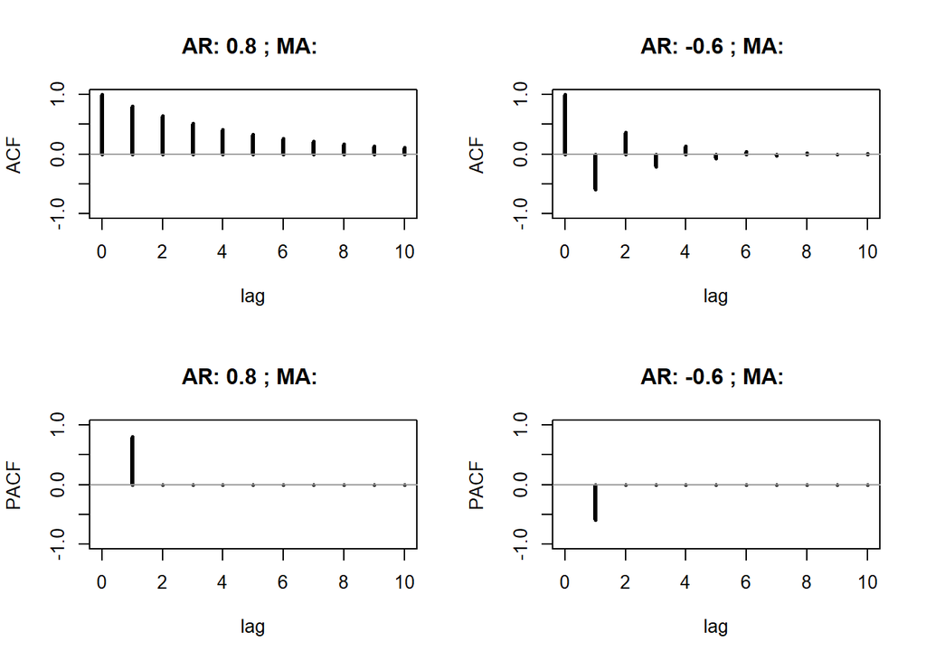

```r
max.lag <- 10
ar<-list(c(.8),c(-.6))
ma<-list(numeric(),numeric())
op<-par(mfrow=c(2,length(ar)))
for (i in (1:length(ar))){
  plot(0:max.lag,ARMAacf(ar=ar[[i]], ma=ma[[i]], lag.max=max.lag), ylab="ACF", xlab="lag",
       main=paste("AR:",paste(ar[[i]],collapse = ", "),"; MA:",paste(ma[[i]],collapse = ", ")), type="h", lwd=3, ylim=c(-1,1), xlim=c(0,max.lag))
  abline(h=0,col=8)
}
for (i in (1:length(ar))){
  plot(1:max.lag,ARMAacf(pacf=TRUE, ar=ar[[i]], ma=ma[[i]], lag.max=max.lag), ylab="PACF", xlab="lag",, main=paste("AR:",paste(ar[[i]],collapse = ", "),"; MA:",paste(ma[[i]],collapse = ", ")), type="h", lwd=3, ylim=c(-1,1), xlim=c(0,max.lag))
  abline(h=0,col=8)
}
```

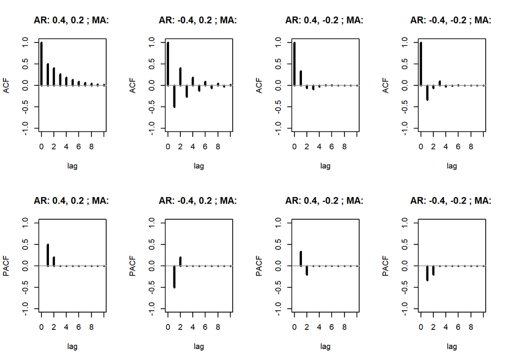

```r
max.lag <- 10
ar<-list(c(.4,.2),c(-.4,.2), c(.4,-.2),c(-.4,-.2))
ma<-list(numeric(),numeric(),numeric(),numeric())
op<-par(mfrow=c(2,length(ar)))
for (i in (1:length(ar))){
  plot(0:max.lag,ARMAacf(ar=ar[[i]], ma=ma[[i]], lag.max=max.lag), ylab="ACF", xlab="lag",
       main=paste("AR:",paste(ar[[i]],collapse = ", "),"; MA:",paste(ma[[i]],collapse = ", ")), type="h", lwd=3, ylim=c(-1,1), xlim=c(0,max.lag))
  abline(h=0,col=8)
}
for (i in (1:length(ar))){
  plot(1:max.lag,ARMAacf(pacf=TRUE, ar=ar[[i]], ma=ma[[i]], lag.max=max.lag), ylab="PACF", xlab="lag",, main=paste("AR:",paste(ar[[i]],collapse = ", "),"; MA:",paste(ma[[i]],collapse = ", ")), type="h", lwd=3, ylim=c(-1,1), xlim=c(0,max.lag))
  abline(h=0,col=8)
}
```

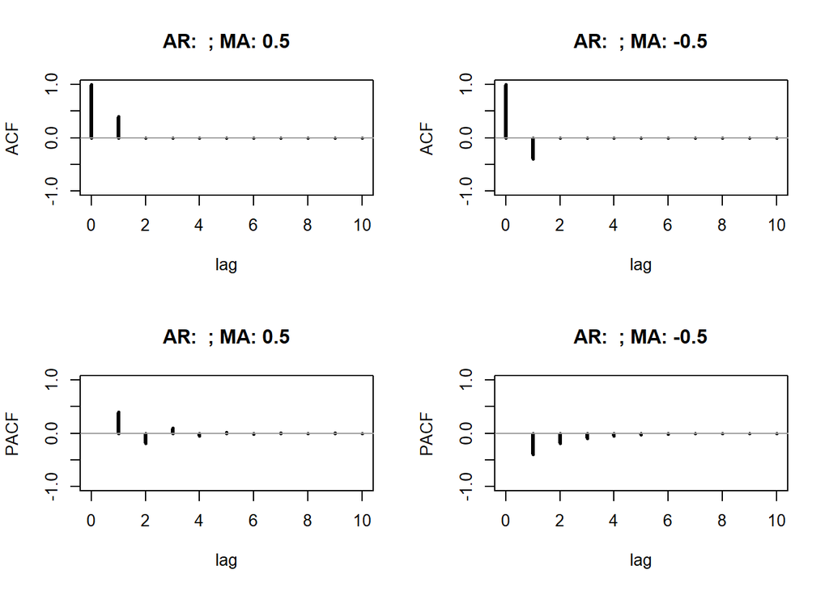

```r
max.lag <- 10
ar<-list(numeric(),numeric())
ma<-list(c(.5),c(-.5))
op<-par(mfrow=c(2,length(ar)))
for (i in (1:length(ar))){
  plot(0:max.lag,ARMAacf(ar=ar[[i]], ma=ma[[i]], lag.max=max.lag), ylab="ACF", xlab="lag",
       main=paste("AR:",paste(ar[[i]],collapse = ", "),"; MA:",paste(ma[[i]],collapse = ", ")), type="h", lwd=3, ylim=c(-1,1), xlim=c(0,max.lag))
  abline(h=0,col=8)
}
for (i in (1:length(ar))){
  plot(1:max.lag,ARMAacf(pacf=TRUE, ar=ar[[i]], ma=ma[[i]], lag.max=max.lag), ylab="PACF", xlab="lag",, main=paste("AR:",paste(ar[[i]],collapse = ", "),"; MA:",paste(ma[[i]],collapse = ", ")), type="h", lwd=3, ylim=c(-1,1), xlim=c(0,max.lag))
  abline(h=0,col=8)
}
```

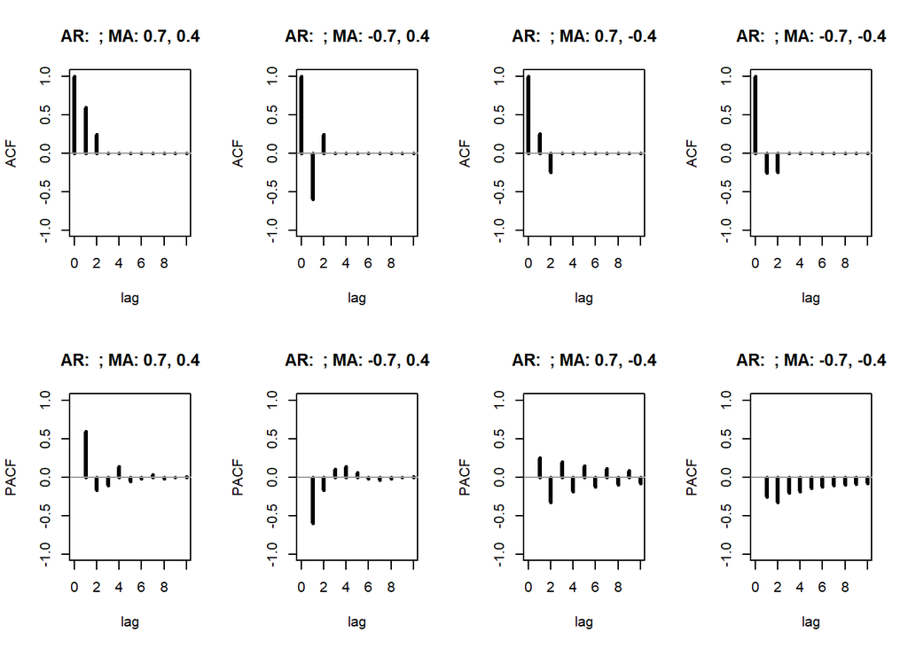

```r
max.lag <- 10
ar<-list(numeric(),numeric(),numeric(),numeric())
ma<-list(c(.7,.4),c(-.7,.4), c(.7,-.4),c(-.7,-.4))
op<-par(mfrow=c(2,length(ar)))
for (i in (1:length(ar))){
  plot(0:max.lag,ARMAacf(ar=ar[[i]], ma=ma[[i]], lag.max=max.lag), ylab="ACF", xlab="lag",
       main=paste("AR:",paste(ar[[i]],collapse = ", "),"; MA:",paste(ma[[i]],collapse = ", ")), type="h", lwd=3, ylim=c(-1,1), xlim=c(0,max.lag))
  abline(h=0,col=8)
}
for (i in (1:length(ar))){
  plot(1:max.lag,ARMAacf(pacf=TRUE, ar=ar[[i]], ma=ma[[i]], lag.max=max.lag), ylab="PACF", xlab="lag",, main=paste("AR:",paste(ar[[i]],collapse = ", "),"; MA:",paste(ma[[i]],collapse = ", ")), type="h", lwd=3, ylim=c(-1,1), xlim=c(0,max.lag))
  abline(h=0,col=8)
}
```

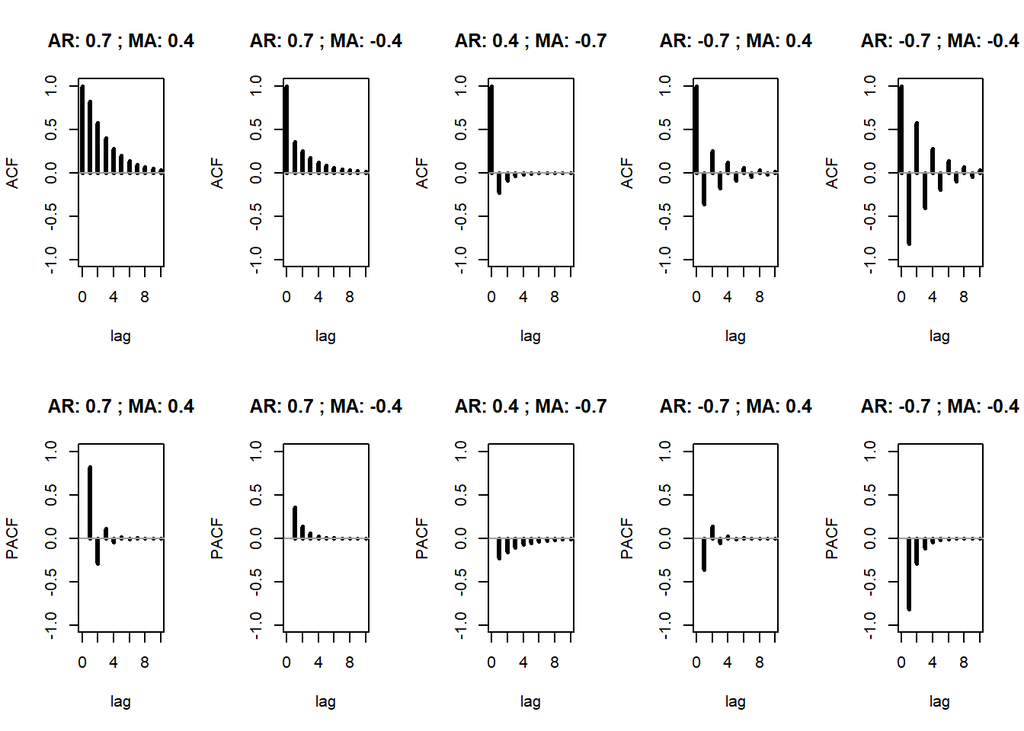

```r
max.lag <- 10
ar<-list(c(.7),c(.7), .4, c(-.7),c(-.7))
ma<-list(c(.4),c(-.4), -.7, c(.4),c(-.4))
op<-par(mfrow=c(2,length(ar)))
for (i in (1:length(ar))){
  plot(0:max.lag,ARMAacf(ar=ar[[i]], ma=ma[[i]], lag.max=max.lag), ylab="ACF", xlab="lag",
       main=paste("AR:",paste(ar[[i]],collapse = ", "),"; MA:",paste(ma[[i]],collapse = ", ")), type="h", lwd=3, ylim=c(-1,1), xlim=c(0,max.lag))
  abline(h=0,col=8)
}
for (i in (1:length(ar))){
  plot(1:max.lag,ARMAacf(pacf=TRUE, ar=ar[[i]], ma=ma[[i]], lag.max=max.lag), ylab="PACF", xlab="lag",, main=paste("AR:",paste(ar[[i]],collapse = ", "),"; MA:",paste(ma[[i]],collapse = ", ")), type="h", lwd=3, ylim=c(-1,1), xlim=c(0,max.lag))
  abline(h=0,col=8)
}
```

# Forecasting with ARMA models

### Prediction in the ARMA(1,1) model

- **ARMA(1,1)**: $X_t=\phi X_{t-1} + w_t + \psi w_{t-1}$.
- Assume that parameters $\phi$, $\psi$, $\sigma^2=\text{Var}(w_t)$ are known.
- Assume that $X_1,\ldots,X_T$ have been observed, and that $w_1=0$.
- Then,
  - $X_{2|1}=E(X_2|X_1,w_1)=\phi X_1$, $\hat{w}_2=X_2-X_{2|1}$.
- For $3 \le t\le T$,
  - $X_{t|t-1}=E(X_t|X_{t-1},\hat{w}_{t-1})=\phi X_{t-1}+\psi \hat{w}_{t-1}$,
  - $\hat{w}_{t}=E(w_t|X_s, s=1,\ldots,t)=X_t-X_{t|t-1}$.
- For $t=T+1$, observe that $\hat{w}_{T+1}= E(w_{T+1}|X_t, t=1,\ldots,T)=E(w_{T+1})=0$. Then
  $$X_{T+1|T}=E(X_{T+1}|X_{t},t=1,\ldots,T)=$$
  $$E(\phi X_T + w_{T+1} + \psi w_{T}|X_{t},t=1,\ldots,T)=
  \phi X_{T}+\psi \hat{w}_{T}.$$
- For $t=T+2$, observe that $\hat{w}_{T+2}= E(w_{T+2}|X_t, t=1,\ldots,T)=E(w_{T+2})=0$. Then
  $$X_{T+2|T}=E(X_{T+2}|X_{t},t=1,\ldots,T)=$$
  $$E(\phi X_{T+1} + w_{T+2} + \psi w_{T+1}|X_{t},t=1,\ldots,T)=
  \phi X_{T+1|T}.$$
- For $k\ge 2$, $\hat{w}_{T+k}=0$ and
  $$X_{T+k|T}=E(X_{T+k}|X_{t},t=1,\ldots,T)=$$
  $$E(\phi X_{T+k-1} + w_{T+k} + \psi w_{T+k-1}|X_{t},t=1,\ldots,T)=$$
  $$\phi X_{T+k-1|T}= \phi^2 X_{T+k-2|T}=\cdots=\phi^{k-1} X_{T+1|T}.$$
- In summary:
  - ${X}_{T+1|T} = \phi X_{T}+ \psi \hat{w}_{T}$,
  - ${X}_{T+k|T} = \phi^{k-1} {X}_{T+1|T}$.

### Estimation in ARMA(1,1)

- **ARMA(1,1)**: $X_t=\phi X_{t-1} + w_t + \psi w_{t-1}$.
- Parameters: $\phi$, $\psi$, $\sigma^2=\text{Var}(w_t)$.
- Conditional estimation: $X_1$ is considered as a known constant (not a random variable), and $w_1=0$.
- For any $\phi$ and $\psi$:
  - $X_{2|1}=E(X_2|X_1,w_1)=\phi X_1$, $\hat{w}_2=X_2-X_{2|1}$.
  - $X_{t|t-1}=E(X_t|X_{t-1},\hat{w}_{t-1})=\phi X_{t-1}+\psi \hat{w}_{t-1}$, $\hat{w}_{t}=X_t-X_{t|t-1}$.
  - $\text{SSE}(\phi,\psi)=\sum_{t=2}^T\hat{w}_{t}^2.$
- $(\hat{\phi},\hat{\psi})=\arg\min_{\phi,\psi} \text{SSE}(\phi,\psi)$.
- $\hat{\sigma}^2=\text{SSE}(\hat{\phi},\hat{\psi})/(T-1)$.

### Prediction in the ARMA(1,1) model with estimated parameters

- With known parameters, we have seen that
  - ${X}_{T+1|T} = \phi X_{T}+ \psi \hat{w}_{T}$,
  - ${X}_{T+k|T} = \phi^{k-1} {X}_{T+1|T}$.
- With estimated parameters:
  - $\hat{X}_{T+1|T} = \hat{\phi} X_{T}+ \hat{\psi} \hat{w}_{T}$,
  - $\hat{X}_{T+k|T} = \hat{\phi}^{k-1} \hat{X}_{T+1|T}$.
- **Predictions variance:** They are computed from the $\text{MA}(\infty)$ expression of the model (see also Section 8.4 in Peña, 2010):
  $$X_t=w_t + \sum_{k=1}^{\infty} \psi_k w_{t-k}
  \Rightarrow
  \text{Var}(X_t)= \sigma^2 \left( 1 + \sum_{k=1}^{\infty} \psi_k^2
  \right)$$
  $$\Rightarrow
  \widehat{\text{Var}}(X_t)= \hat{\sigma}^2
  \left( 1 + \sum_{k=1}^{\infty} \hat{\psi}_k^2 \right).$$

## Prediction for a generic ARMA($p$,$q$) model

$X_t\!=\!\phi_1 X_{t-1}\!+\!\ldots\!+\!\phi_p X_{t-p}\!+\! w_t\!-\!\psi_1 w_{t-1}\!-\!\cdots\!-\!\psi_q w_{t-q}$

Assume that the parameters $\phi_i$, $\psi_j$ are known, and that $X_1,\ldots,X_T$ have been observed. Then
$$X_{T+k|T}\!=\!\phi_1 X_{T+k-1|T}\!+\!\ldots\!+\!\phi_p X_{T+k-p|T}+\!$$
$$w_{T+k|T}\!+\!\psi_1 w_{T+k-1|T}\!+\!\cdots\!+\!\psi_q w_{T+k-q|T},$$
where

- $X_{T+k-i|T}=X_t$ when $t=T+k-i\le T$,
- $w_{T+k-i|T}=0$ when $T+k-i> T$,
- and, for $t=T+k-i\le T$, $w_{T+k-i|T}=\hat{w}_t$ computed recursively for $t\le T$ as $\hat{w}_t=X_t-\hat{X}_t$, with
  $$\hat{X}_t = \!\phi_1 X_{t-1}\!+\!\ldots\!+\!\phi_p X_{t-p}\!+\!
  0\!+\!\psi_1 \hat{w}_{t-1}\!+\!\cdots\!+\!\psi_q \hat{w}_{t-q}.$$
  Parameter estimation is done as we have seen for ARMA(1,1).

# ARIMA models for general time series

We have seen so far:

- If a time series $X_t$ (observed at $t=1,\ldots,T$) is stationary, then ARMA models (including pure AR and MA models) are a useful tool for modeling it and forecasting future values.
- If $X_t$ is not stationary, we decompose it in its structural components, $X_t=\mu_t+S_t+a_t$, where $a_t$ stationary.
  - We have seen how to forecast $\mu_t$ and $S_t$.
  - ARMA models can be used to model and forecast $a_t$.
- Nevertheless, decomposition of $X_t$ is not the only way to transform $X_t$ into a stationary time series.
- **Differentiating** $X_t$ is a useful alternative.

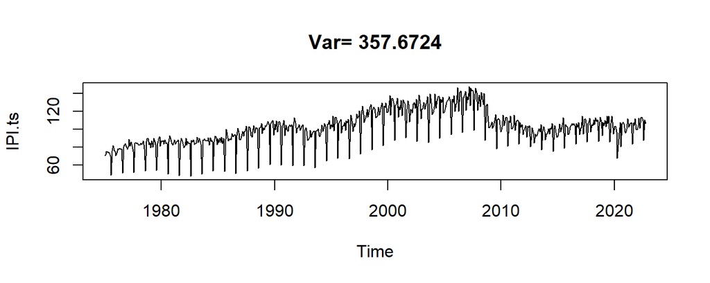

```r
plot(IPI.ts,main=paste("Var=",round(var(IPI.ts),4)))
```

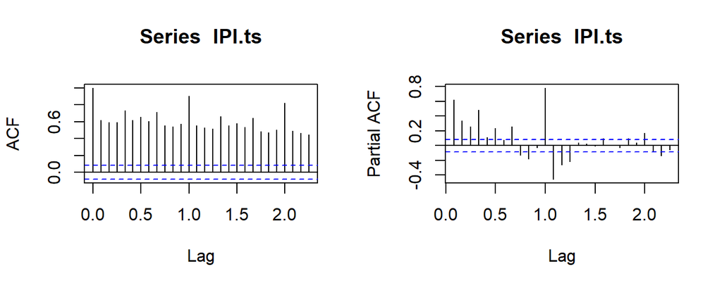

```r
op<-par(mfrow=c(1,2))
acf(IPI.ts)
pacf(IPI.ts)
```

```r
par(op)
```

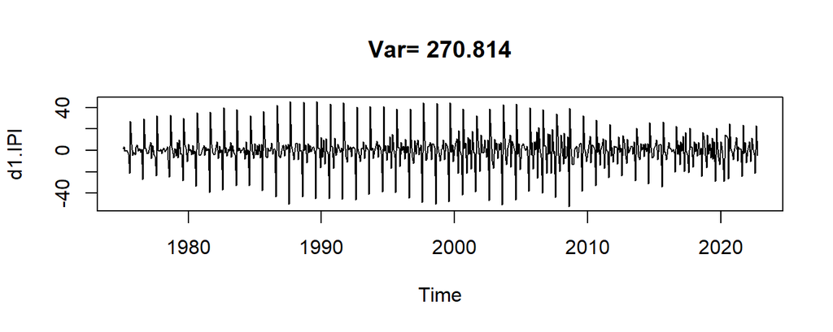

```r
d1.IPI <- diff(IPI.ts, lag = 1)
plot(d1.IPI,main=paste("Var=",round(var(d1.IPI),4)))
```

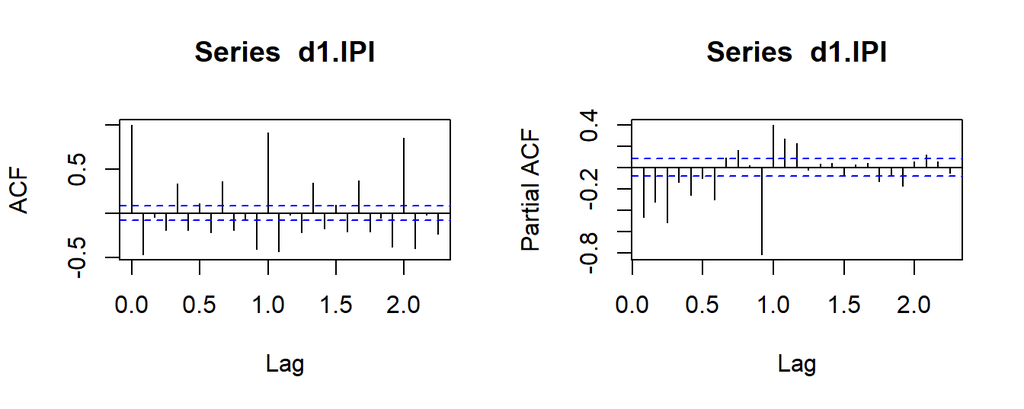

```r
op<-par(mfrow=c(1,2))
acf(d1.IPI)
pacf(d1.IPI)
```

```r
par(op)
```

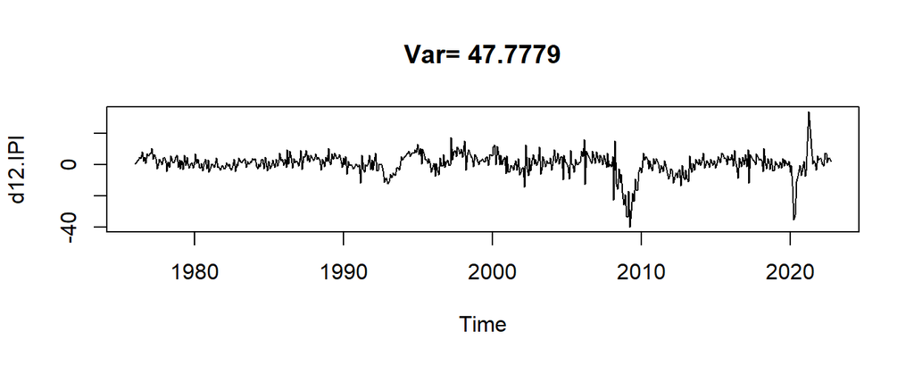

```r
d12.IPI <- diff(IPI.ts, lag = 12)
plot(d12.IPI,main=paste("Var=",round(var(d12.IPI),4)))
```

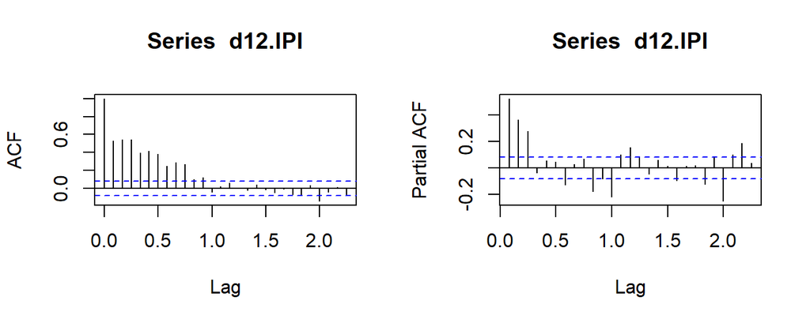

```r
op<-par(mfrow=c(1,2))
acf(d12.IPI)
pacf(d12.IPI)
```

```r
par(op)
```

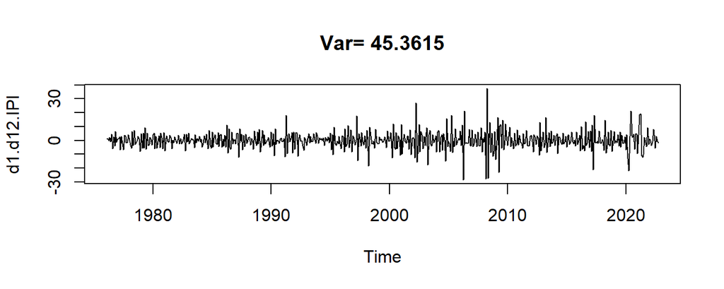

```r
d1.d12.IPI <- diff(diff(IPI.ts, lag = 12), lag=1)
plot(d1.d12.IPI,main=paste("Var=",round(var(d1.d12.IPI),4)))
```

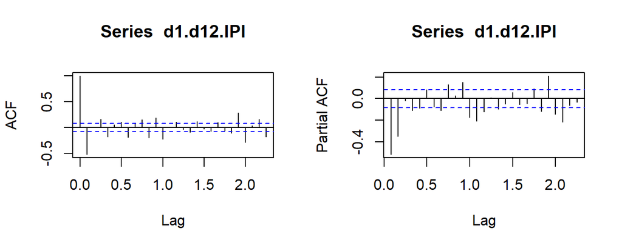

```r
op<-par(mfrow=c(1,2))
acf(d1.d12.IPI)
pacf(d1.d12.IPI)
```

```r
par(op)
```

ARMA(1,1) model for $\Delta \Delta_{12}$IPI, using function `Arima` from library `forecast`:

```r
library(forecast)
arma.1.1.d1.d12.IPI <- Arima(d1.d12.IPI,order=c(1,0,1))
print(arma.1.1.d1.d12.IPI)
```

```
## Series: d1.d12.IPI
## ARIMA(1,0,1) with non-zero mean
##
## Coefficients:
##           ar1      ma1   mean
##       -0.1727  -0.5459  0.003
## s.e.   0.0620   0.0520  0.089
##
## sigma^2 = 29.68:  log likelihood = -1745.79
## AIC=3499.57   AICc=3499.64   BIC=3516.89
```

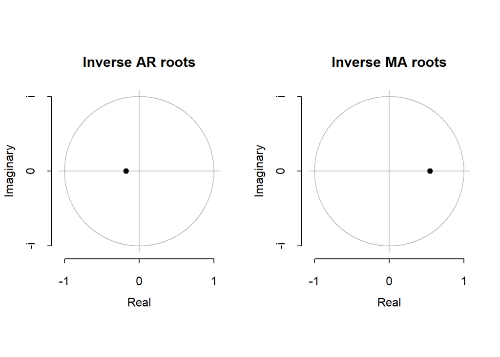

```r
plot(arma.1.1.d1.d12.IPI)
```

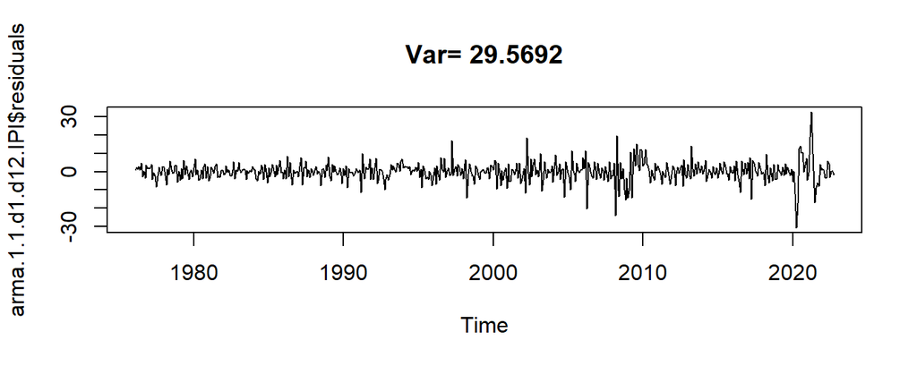

```r
plot(arma.1.1.d1.d12.IPI$residuals,main=paste("Var=",round(var(arma.1.1.d1.d12.IPI$residuals),4)))
```

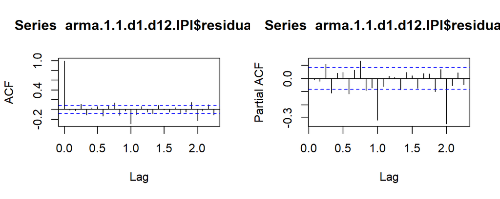

```r
op<-par(mfrow=c(1,2))
acf(arma.1.1.d1.d12.IPI$residuals)
pacf(arma.1.1.d1.d12.IPI$residuals)
```

```r
par(op)
```

## ARIMA and Seasonal ARIMA models

- ARIMA: AutoRegressive Integrated Moving Averages
- **ARIMA($p$,$d$,$q$)**: $\Phi_p(L) \Delta^d X_t = \Psi_q(L) w_t$ $\Leftrightarrow$ $(1\!-\!\phi_1 L \!-\! \cdots \!-\! \phi_p L^p)(1\!-\!L)^d X_t = (1\!+\!\psi_1 L\!+\!\cdots\!+\!\psi_q L^q ) w_t$ $\Leftrightarrow$ $(1\!-\!\delta_1 L \!-\! \cdots \!-\! \delta_{p+d} L^{p+d}) X_t = (1\!+\!\psi_1 L\!+\!\cdots\!+\!\psi_q L^q ) w_t$ $\Leftrightarrow$ $X_t = \delta_1 X_{t-1} \!+\! \cdots \!+\! \delta_{p+d} X_{t-p-d} + w_t \!+\!\psi_1 w_{t-1} \!+\!\cdots\!-\!\psi_q w_{t-q}$
- **ARIMA($p$,$d$,$q$)($P$,$D$,$Q$)**: $\Phi_p(L)\Phi_P^S(L^{12}) \Delta^d\Delta_{12}^D X_t = \Psi_q(L) \Psi_Q(L^{12}) w_t$
- Estimation in R:
  - `arima` in library `stats`
  - `Arima` in library `forecast`
  - `auto.arima` in library `forecast`

Best ARIMA model for IPI, using function `auto.arima` from library `forecast`:

```r
best.arima.IPI <- auto.arima(IPI.ts)
print(best.arima.IPI)
```

```
## Series: IPI.ts
## ARIMA(3,1,1)(1,1,2)[12]
##
## Coefficients:
##          ar1     ar2     ar3      ma1     sar1     sma1     sma2
##       0.1793  0.2287  0.2743  -0.9101  -0.4891  -0.0614  -0.5528
## s.e.  0.1019  0.0854  0.0663   0.0874   0.0959   0.0830   0.0565
##
## sigma^2 = 19.91:  log likelihood = -1636.89
## AIC=3289.77   AICc=3290.03   BIC=3324.41
```

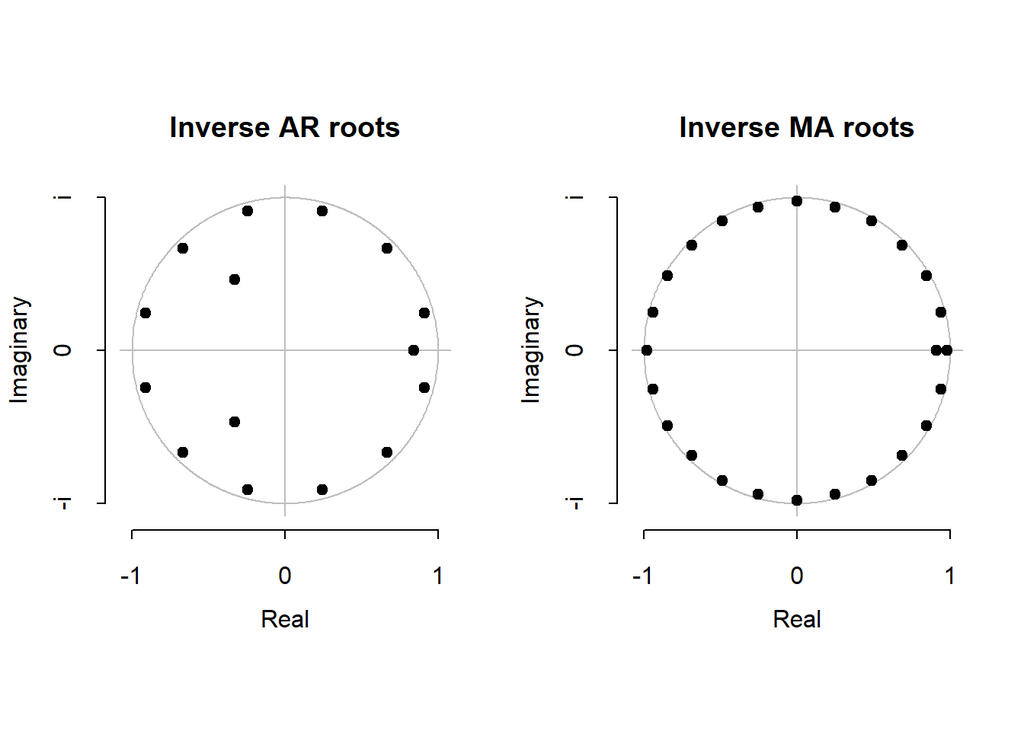

```r
plot(best.arima.IPI)
```

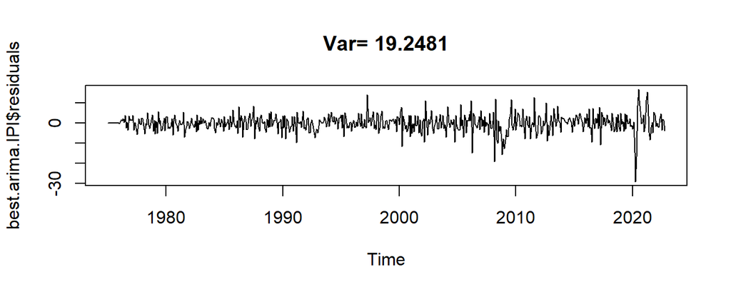

```r
plot(best.arima.IPI$residuals,main=paste("Var=",round(var(best.arima.IPI$residuals),4)))
```

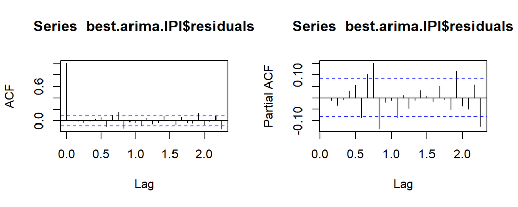

```r
op<-par(mfrow=c(1,2))
acf(best.arima.IPI$residuals)
pacf(best.arima.IPI$residuals)
```

```r
par(op)
```

### The Airlines Model: ARIMA(0,1,1)(0,1,1)$_{12}$

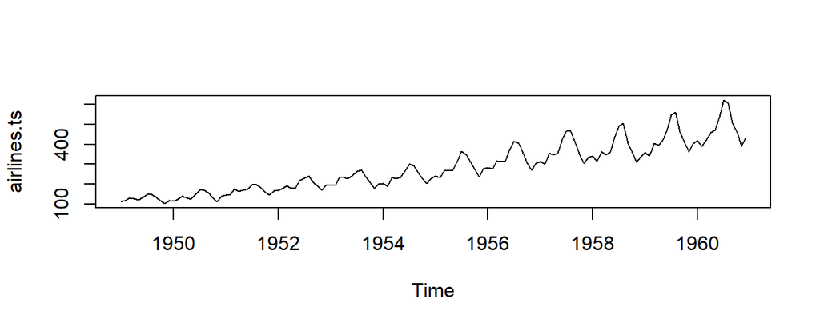

```r
plot(airlines.ts)
```

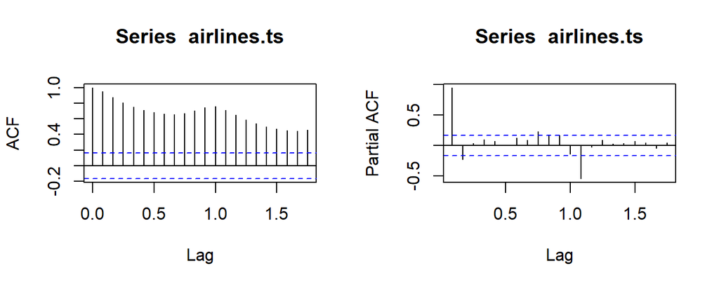

```r
op<-par(mfrow=c(1,2))
acf(airlines.ts)
pacf(airlines.ts)
```

```r
par(op)
```

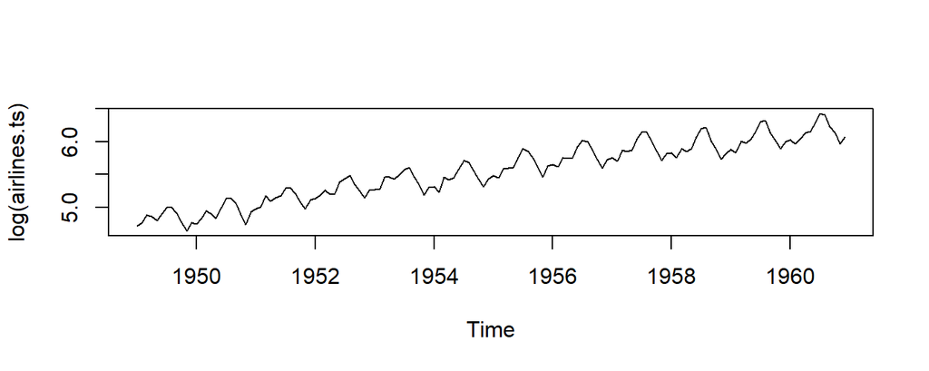

```r
plot(log(airlines.ts))
```

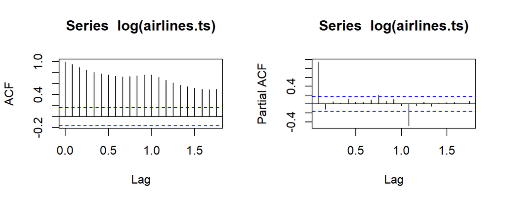

```r
op<-par(mfrow=c(1,2))
acf(log(airlines.ts))
pacf(log(airlines.ts))
```

```r
par(op)
```

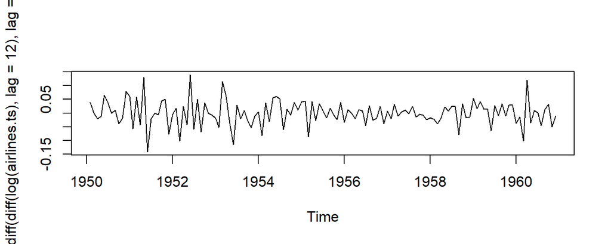

```r
plot(diff(diff(log(airlines.ts),lag=12),lag=1))
```

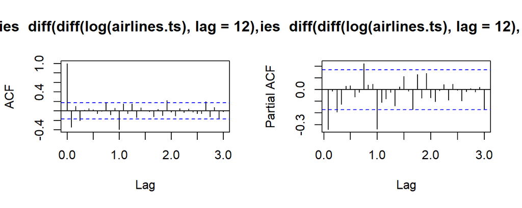

```r
op<-par(mfrow=c(1,2))
acf(diff(diff(log(airlines.ts),lag=12),lag=1),lag.max = 36)
pacf(diff(diff(log(airlines.ts),lag=12),lag=1),lag.max = 36)
```

```r
par(op)
```

**Fitting the Airlines Model**

```r
airlines.model <- Arima(airlines.ts,order=c(0,1,1),seasonal = c(0,1,1),lambda = 0)
print(airlines.model)
```

```
## Series: airlines.ts
## ARIMA(0,1,1)(0,1,1)[12]
## Box Cox transformation: lambda= 0
##
## Coefficients:
##           ma1     sma1
##       -0.4018  -0.5569
## s.e.   0.0896   0.0731
##
## sigma^2 = 0.001371:  log likelihood = 244.7
## AIC=-483.4   AICc=-483.21   BIC=-474.77
```

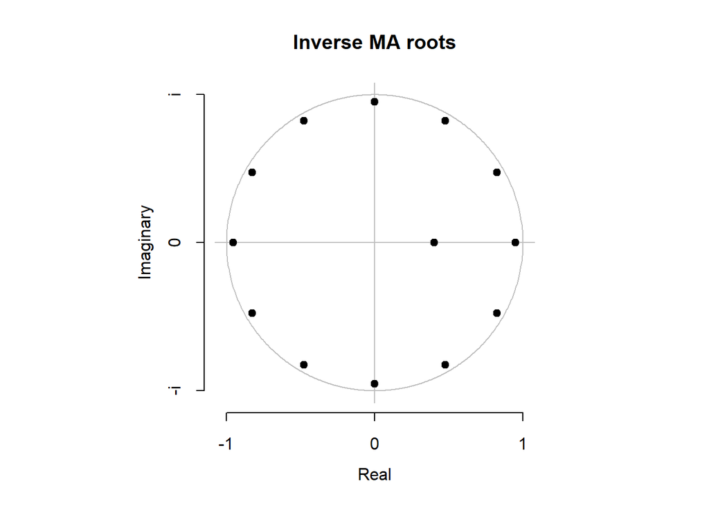

```r
plot(airlines.model)
```

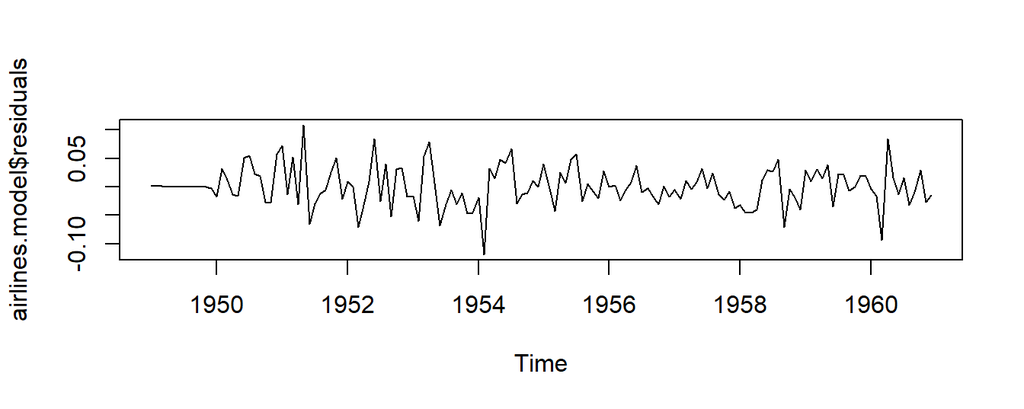

```r
plot(airlines.model$residuals)
```

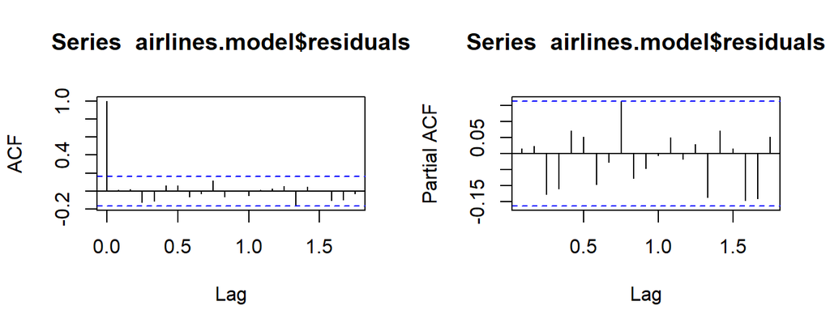

```r
op<-par(mfrow=c(1,2))
acf(airlines.model$residuals)
pacf(airlines.model$residuals)
```

```r
par(op)
```

### Best Seasonal ARIMA model for the Airlines time series

```r
best.airlines <- auto.arima(airlines.ts,lambda = 0)
print(best.airlines)
```

```
## Series: airlines.ts
## ARIMA(0,1,1)(0,1,1)[12]
## Box Cox transformation: lambda= 0
##
## Coefficients:
##           ma1     sma1
##       -0.4018  -0.5569
## s.e.   0.0896   0.0731
##
## sigma^2 = 0.001371:  log likelihood = 244.7
## AIC=-483.4   AICc=-483.21   BIC=-474.77
```

# Forecasting with ARIMA models

## Forecasting with ARIMA models

- Conceptually, forecasting with ARIMA models is similar to forecasting with ARMA models.
- When there is no seasonal part, the basic equation is  
  $X_t = \delta_1 X_{t-1} \!+\! \cdots \!+\! \delta_{p+d} X_{t-p-d} + w_t \!+\!\psi_1 w_{t-1} \!+\!\cdots\!+\!\psi_q w_{t-q}$
- Working with the seasonal part is similar.
- Forecasting with ARIMA models in R:
  - Apply the function `predict` to the output objects (fitted models) of function `arima`.
  - Apply the function `forecast` to the output objects (fitted models) of functions `Arima` or `auto.arima`.
  - The forecasting objects can be plotted using `plot`.
  - When using functions in library `forecast` you can plot predictions using `autoplot` (it requires library `ggplot2`).

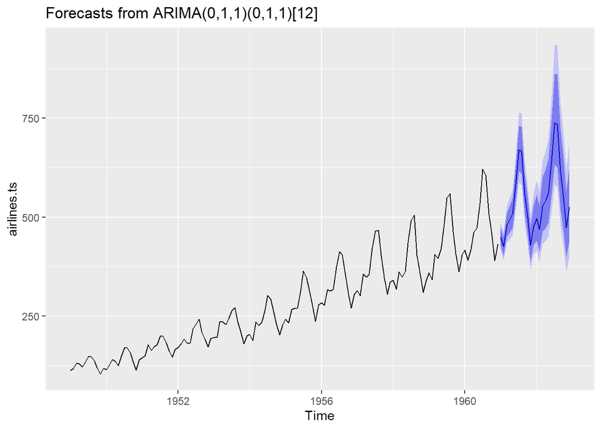

```r
library(ggplot2)
autoplot(forecast(airlines.model))
```

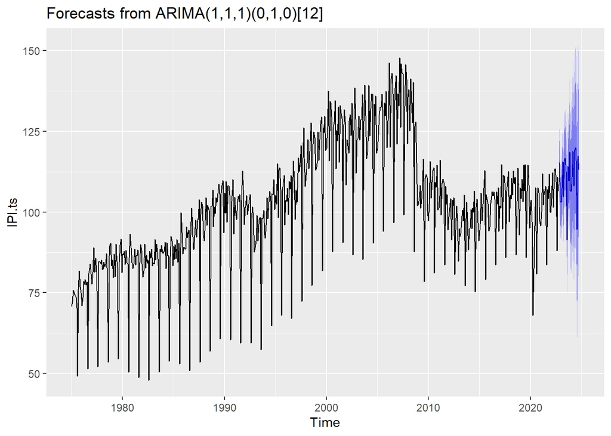

```r
my.arima.IPI <- Arima(IPI.ts,order=c(1,1,1),seasonal=c(0,1,0))
autoplot(forecast(my.arima.IPI))
```

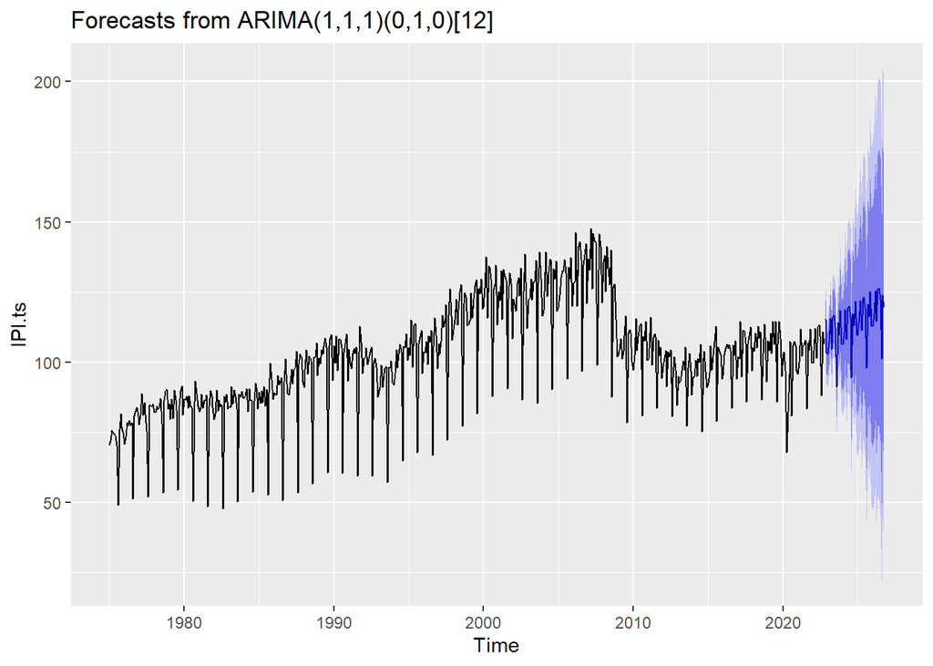

```r
autoplot(forecast(my.arima.IPI,h=48))
```